# Lesson1_Solution

MAJ Daniel Baller

January 4, 2022

Welcome to MA388 Sabermetrics!

The purpose of today is to get to know each other and get started looking at some baseball data. If you’re not proficient in R yet, no worries, please feel free to ask me or get help from someone around you.

### Data Sourcesw

There are 4 main sources of data that we will use for the course. What info can we take from each one?

- **The Lahman Database:** 1871-2019 Basic season count statistics for for batting, pitching, and fielding.
- **Retrosheet:** Game-by-game summaries and play-by-play data of most games since 1921
- **PITCHf/x:** pitch-by-pitch data detailing the flight of every pitch since 2008.
- **Statcast via Baseball Savant:** detailed information on the position and movement of all players and the ball throughout the game since 2015.

Let’s take a look at some player data.

```r
#Growing up my favorite player was Randy Johnson back when he was playing for the mariners.
library(Lahman)
library(tidyverse)

#get Randy Johnson's player ID
People %>%
  filter(nameLast == "Johnson", nameFirst == "Randy")
```

```
##    playerID birthYear birthMonth birthDay birthCountry birthState    birthCity
## 1 johnsra03      1958          8       15          USA         FL        Miami
## 2 johnsra04      1956          6       10          USA         CA    Escondido
## 3 johnsra05      1963          9       10          USA         CA Walnut Creek
##   deathYear deathMonth deathDay deathCountry deathState deathCity nameFirst
## 1        NA         NA       NA         <NA>       <NA>      <NA>     Randy
## 2        NA         NA       NA         <NA>       <NA>      <NA>     Randy
## 3        NA         NA       NA         <NA>       <NA>      <NA>     Randy
##   nameLast      nameGiven weight height bats throws      debut  finalGame
## 1  Johnson Randall Stuart    195     74    L      L 1980-07-05 1982-10-03
## 2  Johnson  Randall Glenn    190     73    R      R 1982-04-27 1984-09-30
## 3  Johnson  Randall David    225     82    R      L 1988-09-15 2009-10-04
##    retroID   bbrefID deathDate  birthDate
## 1 johnr101 johnsra03      <NA> 1958-08-15
## 2 johnr001 johnsra04      <NA> 1956-06-10
## 3 johnr005 johnsra05      <NA> 1963-09-10
```

Let’s take a look at Randy Johnson’s season statistics using the Pitching table. If you don’t understand the code at this point, it’s okay!

```r
#I want to see the opponents batting average for each team that Randy Johnson played for.

#Extract Randy Johnson's seasonal pitching data
johnson = Pitching %>%
  filter(playerID == "johnsra05")

#calculate opponents batting average by team
johnson %>%
  group_by(teamID) %>%
  summarize(BAO = sum(H)/sum(BFP), Years = n())
```

```
## # A tibble: 6 x 3
##   teamID   BAO Years
##   <fct>  <dbl> <int>
## 1 ARI    0.202     8
## 2 HOU    0.173     1
## 3 MON    0.206     2
## 4 NYA    0.225     2
## 5 SEA    0.183    10
## 6 SFN    0.235     1
```

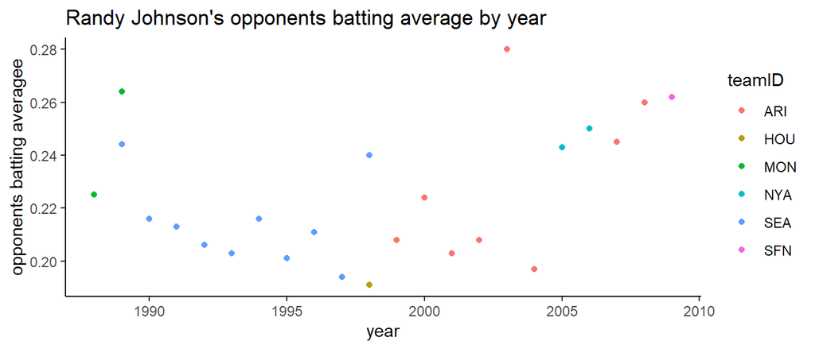

```r
#Plot his batting average by season
johnson %>%
  ggplot(aes(x = yearID, y = BAOpp, color = teamID)) +
  geom_point() +
  labs(x = "year",
       y = "opponents batting averagee",
       title = "Randy Johnson's opponents batting average by year")+
  theme_classic()
```

Who is your favorite baseball player?

Find your favorite player’s in the Player table below. This ID will be used to access this player’s data in other databases. See my code above for some assistance.

Find out something interesting about your player using the Batting, Pitching, or Fielding tables. Feel free to use my code above.